# Larval zebrafish Trust STK_50 min

#### Z Scores Plot

We will plot the individual and averaged Z scores using both the across and within chip analyses.

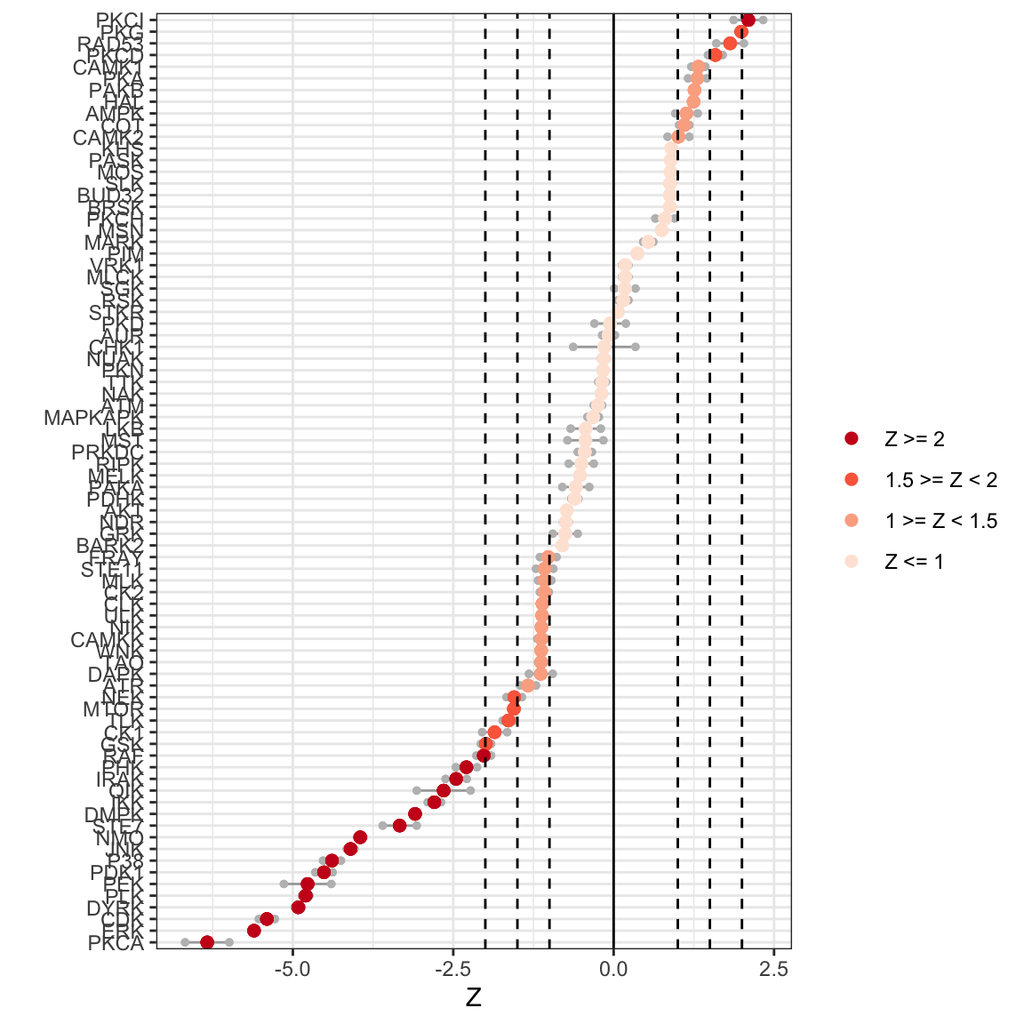

Waterfall plot of the Z Scores of each kinase family

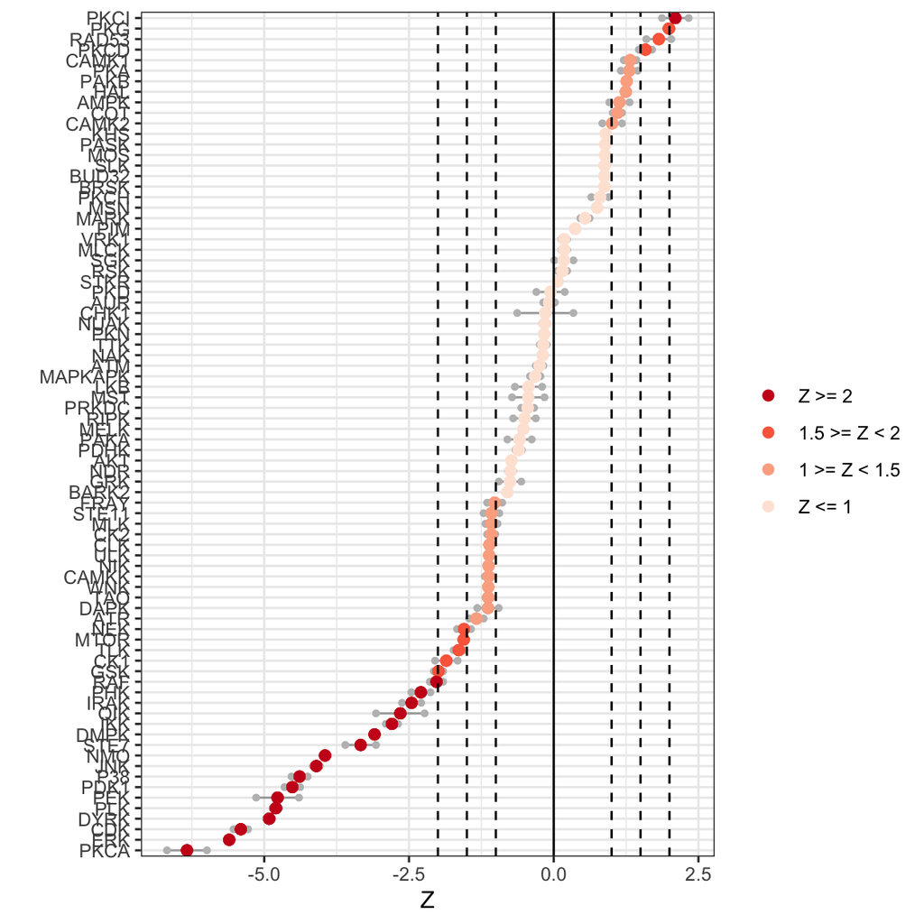

Waterfall plot of the Z Scores of each kinase family

#### Reverse KRSA Plot

We will use the reverse KRSA plot function, to plot the log2 fold change values for all peptides mapped to kinase hits. This will help us examine the activity of the kinase

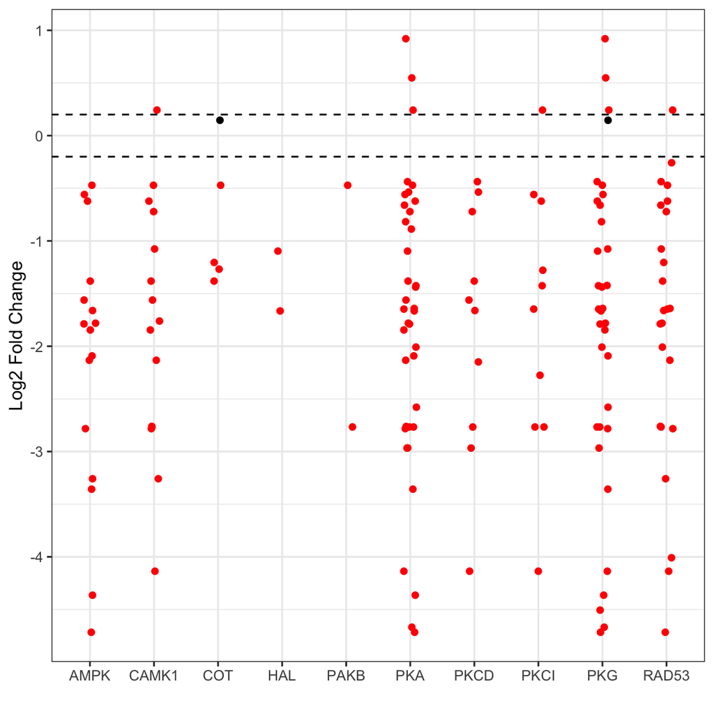

Kinase Activity summary for each kinase family based on peptide phosphorylation

#### Coverage Plot

To view the coverage of kinases across the full list of peptides on the chip, we will use the coverage plot function

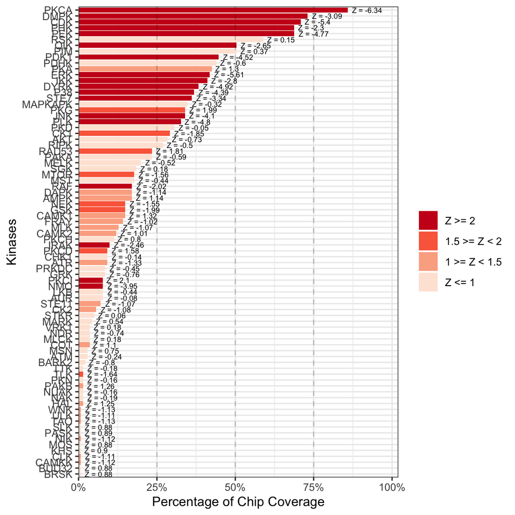

Percentage of peptides each kinase family phosphorylates

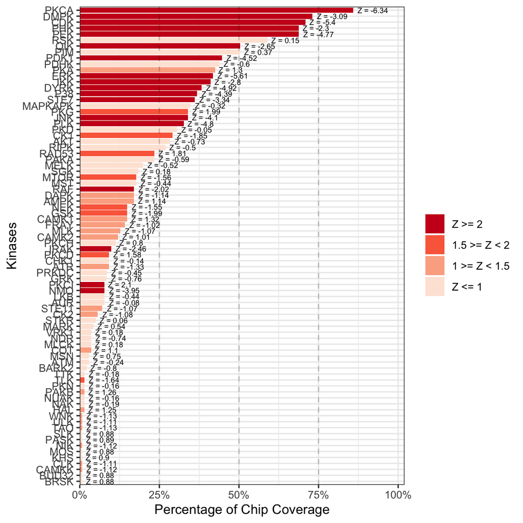

Percentage of peptides each kinase family phosphorylates

#### Ball Model Network

We will view the ball model network function, to generate a model representing the protein-protein interactions between kinases

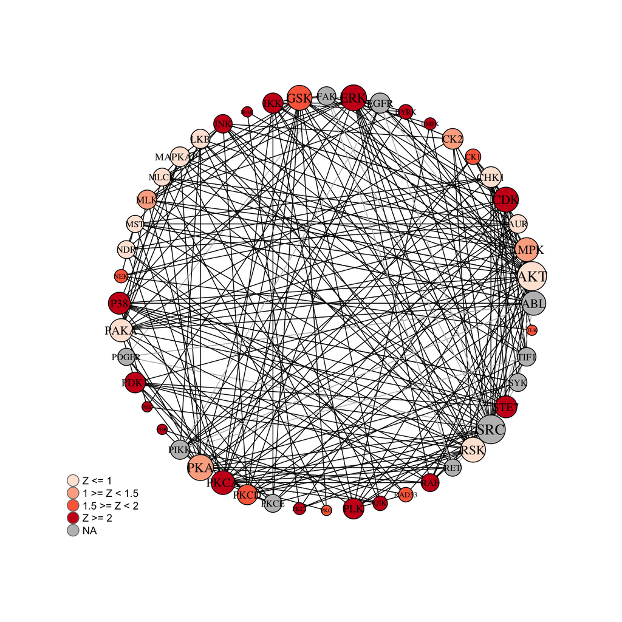